# Reproducible data reports with Quarto

NHS R Conference 2022

Rhian Davies @StatsRhian

## Welcome

- **Workspace**: [posit.cloud/spaces/293797](https://posit.cloud/spaces/293797/content/)
- **Slides**: github.com/jumpingrivers/2022-nhs-r-quarto

# Hello 👋

A bit about me

# Jumping Rivers?

Data Science Consultancy and Training

# What we do

- All things data science
- Training
- Machine learning, DevOps, infrastructure
- Managed Posit services
- Dashboard development and deployment

📨 hello@jumpingrivers.com

## Timings 🕑

- **14:00 - 15:00** Part 1
- **15:00 - 15:15** 15 minute break
- **15:15 - 16:15** Part 2
- **16:15 - 16:30** Q & A

# Ask questions throughout 🙋

# What is Quarto?

## Quarto?

- Open-source scientific and technical publishing system
- Write documents that combine code with text
- Created by [Posit](https://posit.co/)
- Similar to R Markdown, but without a dependency on R
- Multiple language and multiple output formats
- File extension `.qmd`

## Gallery

Let’s look at some [examples](https://quarto.org/docs/gallery/)

## What about R Markdown?

- R Markdown isn’t going anywhere
- Quarto has great [documentation](https://quarto.org/docs/get-started/)
- Quarto is independent from R
- Quarto is very user friendly
- Can still render most R Markdown files without modification

# Your first Quarto document

## Creating a new Quarto document

- File > New File > Quarto Document
- Set title and author
- Click **Create**
- Save and click **Render**

## It’s not an R package but…

```r
library("quarto")
quarto_render("document.qmd")
```

## YAML header

```yaml
---
title: "A very cool title"
format: html
---
```

**Note**

YAML: Yet Another Markup Language

## Task 1: Your first Quarto document

1. File > New File > Quarto Document
2. Click **Create Empty Document**
3. Add some YAML declaring a title, author and HTML format
4. Add a sentence
5. Tick `Render on Save`
6. Save your document and click `Render`

```yaml
---
title: "My first Quarto report"
author: "Rhian Davies"
format: html
---
```

`05:00`

# Adding content

## Including content

- Text
- Links
- Images
- Code text
- Embedded tables and plots
- Equations
- References

[Documentation](https://quarto.org/docs/authoring/markdown-basics.html)

## Including images

- Lots of ways to add images to a Quarto document
- Easiest is to use the Visual editor
- Click **Insert –> Figure/Image**

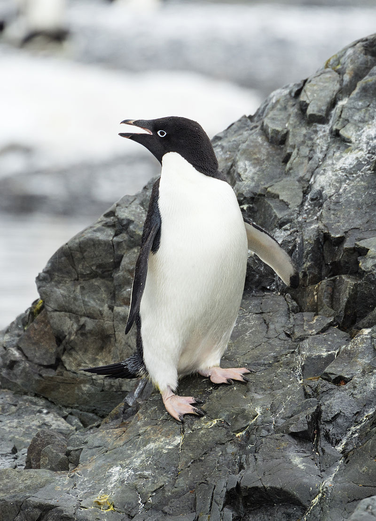

By Andrew Shiva/Wikipedia, CC BY-SA 4.0

## Task 2: Adelie Penguins 🐧

1. Go to [wikipedia.org/wiki/Adelie_penguin](https://en.wikipedia.org/wiki/Ad%C3%A9lie_penguin)
2. Copy the first sentence into a Quarto document.
3. Match the formatting (italics, bold, links)
4. Add an image of the Adelie Penguin (there’s one in the tasks folder)
5. Using the visual editor, can you add alt text to your image?

`10:00`

# Including code

## Code blocks

- Anything you can do in code, you can add to your document.
- For example we could load data

````markdown
```{r}
penguins = readr::read_csv(
  "https://raw.githubusercontent.com/rfordatascience/tidytuesday/master/data/2020/2020-07-28/penguins.csv"

)
```
````

- Can have as many code blocks as you like
- `Ctrl + Alt + I` in the RStudio IDE

## Order matters

- Code blocks are executed in order

```r
x
```

```
Error in eval(expr, envir, enclos): object 'x' not found
```

```r
x = 5
```

## Your environment matters

Remember to load any libraries you might need.

```r
penguins %>%
  group_by(species) %>%
  summarise(avg_bill = mean(bill_depth_mm))
```

```
Error in penguins %>% group_by(species) %>% summarise(avg_bill = mean(bill_depth_mm)): could not find function "%>%"
```

## Code block options

Included in a special comment `#|` at the top of the block

| Option | Purpose | Default value |
| --- | --- | --- |
| `echo` | Show/hide code blocks in the output | `true` |
| `eval` | Whether to evaluate code within the block | `true` |
| `warning` | Show/hide messages/warnings produced by code in the output | `true` |

[More info](https://quarto.org/docs/computations/execution-options.html)

## Code collapsing

```yaml
#| echo: fenced
#| code-fold: true
```

````markdown
```{r}
#| warning: false
#| code-fold: true
library("dplyr")
library("tidyr")
library("stringr")
library("ggplot2")
```
````

## Global code block options

```yaml
---
title: "Global code block options"
execute:
echo: false
---
```

## Inline code

````markdown
```{r}
avg_bill =
  penguins %>%
  filter(species == "Adelie") %>%
  pull(bill_length_mm) %>%
  mean(na.rm = TRUE) %>%
  round()
```
````

The average bill length of the Adelie penguin is 39mm.

## Task 3: Running some code 🐧

1. Open the document `task3.qmd`
2. Try to render it. Why does it not work?
3. Directly under the analysis subheading, add a code block to load the {dplyr}, {readr} and {tidyr} packages
4. Hide the code block and stop the packages messages from displaying
5. Use in-line code to add a sentence about the largest recorded bill length of an Adelie penguin.

```r
library("dplyr")
library("readr")
library("tidyr")
```

`10:00`

# Graphs, Tables and params

## Graphs

````markdown
```{r}
#| fig-cap: "Flipper vs bill length for three years."
#| fig-width: 8
#| output-location: slide
ggplot(penguins, aes(x = bill_length_mm,
                     y = flipper_length_mm,
                     colour = species)) +
  geom_point() +
  geom_smooth(method = "lm", se = FALSE) +
  facet_wrap(~year) +
  theme_minimal()
```
````

## Graphs

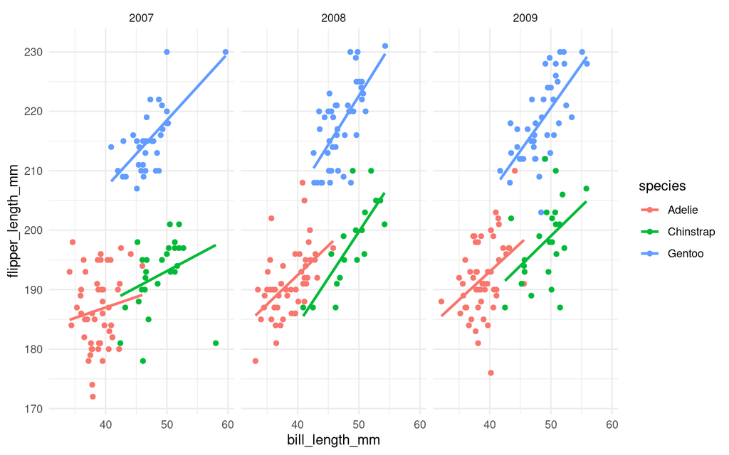

Flipper vs bill length for three years.

## Tables

Many table packages in R. Notable ones:

- `knitr::kable()`
- {reactable}
- {gt}
- {flextable}
- {DT}

## Parameterised reports

Allow you to define parameters in YAML

```yaml
---
title: "A report on penguins"
format: html
params:
    species: Adelie
---
```

And use them in your code chunks

````markdown
```{r}
#| eval: false
penguins %>%
  filter(species = params$species)
```
````

## Task 4: Tables and graphs 🐧

1. Open the document `task4.qmd`
2. Change the displayed `table` to be a reactable table with `reactable::reactable()`
3. Add a caption to the plot with the `fig-cap:` code block option
4. Change the `species:` param in the YAML from “Adelie” to “Gentoo”

`10:00`

# Wrap up 🏁

## Links & Resources

- Quarto docs: [quarto.org](https://quarto.org/)
- Thomas Mock webinar: [jthomasmock.github.io/quarto-2hr-webinar](https://jthomasmock.github.io/quarto-2hr-webinar/)
- Learn with us at [jumpingrivers.com/training/](https://www.jumpingrivers.com/training/all-courses/)
- These materials at [jumpingrivers.github.io/2022-nhs-r-quarto](https://jumpingrivers.github.io/2022-nhs-r-quarto/)

[figure not shown]